# Experiment — Per-Node NTC2/NTC3 → NTC1 Calibration

Author

Thom Laepple

Published

June 30, 2026

## Idea

The three NTCs of a snowmelt node sit ~4 cm apart and should see almost the same temperature, yet NTC2 (and to a lesser degree NTC3) show a systematic gain/offset relative to NTC1 (see the NTC2-Diagnose in `decode_field.qmd`). Here we **treat NTC1 as truth** and, *per node separately*, fit a linear calibration

$$\widehat{\text{NTC1}} = a + b \cdot \text{NTC}_k \qquad (k = 2, 3)$$

This is purely an experiment — it does not change the field decoder.

```r
library(dplyr); library(tidyr); library(ggplot2); library(patchwork)

IMEI    <- "300434065508020"   # snowmelt NEWGRIP (ntc1/ntc2/testSB)
fields  <- c("ntc1", "ntc2", "testSB")
n_nodes <- 24L
spacing <- 4L                  # cm between NTCs within a node
N_TRAIN <- 4L                  # fit on the first four messages, test on the rest
```

## Decode the messages

```r
# Self-contained snowchain/snowmelt binary reader (same logic as decode_field.qmd).
bin_field_bytes <- function(f) {
  if (f %in% c("ntc1", "ntc2", "testSB", "pressure")) return(3L)
  if (f == "gnd") return(2L); stop("Unknown field: ", f)
}
read_snowchain_bin <- function(path, fields, n_nodes) {
  raw <- readBin(path, what = "raw", n = file.info(path)$size)
  n <- length(raw); ints <- as.integer(raw); has_sep <- ints[5] == 0x7CL
  be_uint <- function(b) sum(as.integer(b) * 256^rev(seq_along(b) - 1L))
  be_sint <- function(b) { v <- be_uint(b); bits <- 8L * length(b)
    if (v >= 2^(bits - 1L)) v - 2^bits else v }
  nf <- length(fields)
  widths <- c(3L, rep(sapply(fields, bin_field_bytes), n_nodes), 2L)
  signed <- c(TRUE, rep(fields != "pressure", n_nodes), FALSE); n_val <- length(widths)
  decode_one <- function(b, w, sgn) {
    if (length(b) != w) return(NA_real_); if (sgn) be_sint(b) else be_uint(b) }
  if (has_sep) {
    sp <- which(ints == 0x7CL); sp <- sp[sp >= 5L]
    fstart <- sp + 1L; fend <- c(sp[-1] - 1L, n)
    vals <- lapply(seq_len(min(length(sp), n_val)), function(i)
      decode_one(raw[fstart[i]:fend[i]], widths[i], signed[i]))
  } else {
    pos <- 5L; vals <- vector("list", n_val)
    for (i in seq_len(n_val)) { w <- widths[i]
      if (w == 3L && pos + 3L <= n && all(ints[pos:(pos + 3L)] == c(1L, 0L, 0L, 0L))) {
        vals[[i]] <- NA_real_; pos <- pos + 4L
      } else if (i == n_val && pos + w - 1L > n && pos <= n) {
        vals[[i]] <- be_uint(raw[pos:n]) * 256L^(w - (n - pos + 1L)); pos <- n + 1L
      } else { vals[[i]] <- decode_one(raw[pos:(pos + w - 1L)], w, signed[i]); pos <- pos + w }
    }
  }
  nv <- vals[2:(1L + n_nodes * nf)]
  list(time_unix = be_uint(raw[1:4]),
       nodes = lapply(seq_len(n_nodes), function(i)
         setNames(nv[((i - 1L) * nf + 1L):(i * nf)], fields)))
}
NTCcounts2temp <- function(c) {
  H <- (-c * 1e6) / (c - 33554432); r <- (H * 499000) / (499000 - H)
  1 / ((1 / 3380) * log(r / 10000) + 1 / 298.15) - 273.15
}
```

```r
# Use the same message set as the field decoder: all of this IMEI's files,
# EXCEPT -2 (the head was not yet erected at that time).
files <- Sys.glob(sprintf("../testdata/%s-*.bin", IMEI))
files <- files[!grepl(sprintf("%s-2\\.bin$", IMEI), files)]

all <- lapply(files, read_snowchain_bin, fields = fields, n_nodes = n_nodes)
ord <- order(sapply(all, `[[`, "time_unix"))
all <- all[ord]; files <- files[ord]
times <- as.POSIXct(sapply(all, `[[`, "time_unix"), origin = "1970-01-01", tz = "UTC")
n_msg <- length(all)

# Temperature matrices: node (row) × message (column).
tmat <- function(f) sapply(all, function(b) sapply(b$nodes, function(nd) NTCcounts2temp(nd[[f]])))
T1 <- tmat("ntc1"); T2 <- tmat("ntc2"); T3 <- tmat("testSB")

train <- seq_len(N_TRAIN)            # first four
test  <- setdiff(seq_len(n_msg), train)  # the rest (here: the 5th)

knitr::kable(
  data.frame(`#` = seq_len(n_msg), file = basename(files),
             time_UTC = format(times, "%Y-%m-%d %H:%M"),
             role = ifelse(seq_len(n_msg) %in% train, "train (fit)", "TEST (held out)"),
             check.names = FALSE),
  caption = "Messages used")
```

Messages used

| # | file | time_UTC | role |
| --- | --- | --- | --- |
| 1 | 300434065508020-3.bin | 2026-06-29 18:16 | train (fit) |
| 2 | 300434065508020-4.bin | 2026-06-29 22:15 | train (fit) |
| 3 | 300434065508020-5.bin | 2026-06-30 02:15 | train (fit) |
| 4 | 300434065508020-6.bin | 2026-06-30 06:15 | train (fit) |
| 5 | 300434065508020-7.bin | 2026-06-30 10:15 | TEST (held out) |
| 6 | 300434065508020-8.bin | 2026-06-30 14:15 | TEST (held out) |

## Fit per node and apply

```r
# For each node, regress NTC1 (truth) on NTC_k over the TRAINING messages, then
# predict NTC1 from NTC_k for ALL messages. Node 24 NTC3 is defective (NA) → its
# fit is skipped and stays NA.
calibrate <- function(Tsensor) {
  a <- b <- rep(NA_real_, n_nodes)
  pred <- matrix(NA_real_, n_nodes, n_msg)
  for (i in seq_len(n_nodes)) {
    y <- T1[i, train]; x <- Tsensor[i, train]
    ok <- is.finite(x) & is.finite(y)
    if (sum(ok) >= 2L) {
      cf <- coef(lm(y ~ x))
      a[i] <- cf[1]; b[i] <- cf[2]
      pred[i, ] <- a[i] + b[i] * Tsensor[i, ]
    }
  }
  list(a = a, b = b, pred = pred)
}
cal2 <- calibrate(T2)   # NTC2 → NTC1
cal3 <- calibrate(T3)   # NTC3 → NTC1

# Tidy frame: expand.grid puts node fastest, matching column-major as.vector().
df <- expand.grid(node = seq_len(n_nodes), msg = seq_len(n_msg))
df$time     <- times[df$msg]
df$set      <- ifelse(df$msg %in% train, "train", "test")
df$NTC1     <- as.vector(T1)
df$NTC2     <- as.vector(T2);       df$NTC3     <- as.vector(T3)
df$NTC2_cal <- as.vector(cal2$pred); df$NTC3_cal <- as.vector(cal3$pred)

# Long residual table: (sensor, raw|cal) minus NTC1.
res <- df |>
  transmute(node, msg, time, set,
            `NTC2 raw` = NTC2 - NTC1, `NTC2 cal` = NTC2_cal - NTC1,
            `NTC3 raw` = NTC3 - NTC1, `NTC3 cal` = NTC3_cal - NTC1) |>
  pivot_longer(starts_with("NTC"),
               names_to = c("sensor", "type"), names_sep = " ",
               values_to = "resid") |>
  filter(is.finite(resid))
```

The fitted per-node coefficients (slope `b` ≈ relative gain to NTC1, intercept `a` ≈ offset in °C):

```r
coef_tab <- bind_rows(
  data.frame(sensor = "NTC2", slope = cal2$b, intercept = cal2$a),
  data.frame(sensor = "NTC3", slope = cal3$b, intercept = cal3$a)
) |>
  group_by(sensor) |>
  summarise(`slope ⌀`     = mean(slope, na.rm = TRUE),
            `slope sd`     = sd(slope,   na.rm = TRUE),
            `intercept ⌀` = mean(intercept, na.rm = TRUE),
            `intercept sd` = sd(intercept, na.rm = TRUE),
            `n nodes`      = sum(is.finite(slope)), .groups = "drop")
knitr::kable(coef_tab, digits = 3,
             caption = "Per-node calibration coefficients (mean over nodes)")
```

Per-node calibration coefficients (mean over nodes)

| sensor | slope ⌀ | slope sd | intercept ⌀ | intercept sd | n nodes |
| --- | --- | --- | --- | --- | --- |
| NTC2 | 0.974 | 0.028 | -0.225 | 0.316 | 24 |
| NTC3 | 1.007 | 0.021 | 0.118 | 0.232 | 23 |

## Does it generalise? (RMSE before vs after)

```r
rmse_tab <- res |>
  mutate(set = ifelse(set == "test", "TEST (5th)", "train")) |>
  group_by(sensor, set, type) |>
  summarise(rmse = sqrt(mean(resid^2)), mae = mean(abs(resid)), .groups = "drop") |>
  pivot_wider(names_from = type, values_from = c(rmse, mae)) |>
  mutate(`RMSE improvement` = sprintf("%.0f %%", 100 * (rmse_raw - rmse_cal) / rmse_raw)) |>
  select(sensor, set,
         `RMSE raw` = rmse_raw, `RMSE cal` = rmse_cal, `RMSE improvement`,
         `MAE raw`  = mae_raw,  `MAE cal`  = mae_cal)
knitr::kable(rmse_tab, digits = 3,
             caption = "RMSE / MAE of (sensor − NTC1) in °C, raw vs calibrated")
```

RMSE / MAE of (sensor − NTC1) in °C, raw vs calibrated

| sensor | set | RMSE raw | RMSE cal | RMSE improvement | MAE raw | MAE cal |
| --- | --- | --- | --- | --- | --- | --- |
| NTC2 | TEST (5th) | 0.584 | 0.460 | 21 % | 0.492 | 0.397 |
| NTC2 | train | 0.288 | 0.178 | 38 % | 0.220 | 0.143 |
| NTC3 | TEST (5th) | 0.331 | 0.262 | 21 % | 0.249 | 0.189 |
| NTC3 | train | 0.202 | 0.136 | 32 % | 0.152 | 0.100 |

## Plots

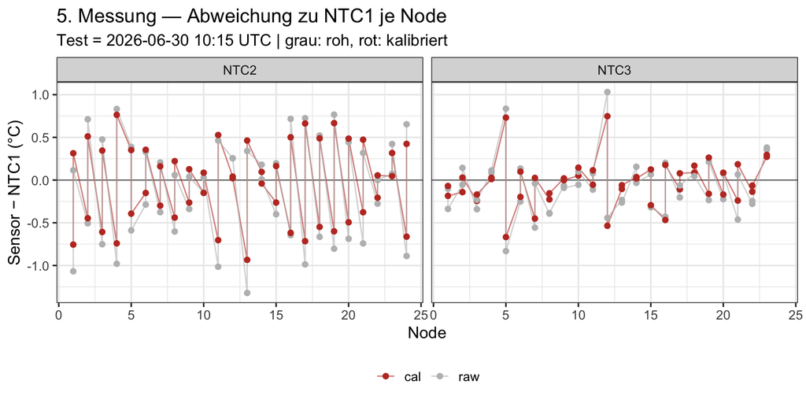

```r
res |> filter(set == "test") |>
  ggplot(aes(x = node, y = resid, colour = type)) +
  geom_hline(yintercept = 0, linewidth = 0.4, colour = "grey40") +
  geom_line(alpha = 0.6, linewidth = 0.5) + geom_point(size = 1.8) +
  facet_wrap(~ sensor) +
  scale_colour_manual(values = c(raw = "#bdbdbd", cal = "#c0392b")) +
  labs(title = "5. Messung — Abweichung zu NTC1 je Node",
       subtitle = sprintf("Test = %s UTC | grau: roh, rot: kalibriert",
                          format(times[test[1]], "%Y-%m-%d %H:%M")),
       x = "Node", y = "Sensor − NTC1 (°C)", colour = NULL) +
  theme_bw(base_size = 13) + theme(legend.position = "bottom")
```

### Residual distribution — train vs. test, raw vs. calibrated

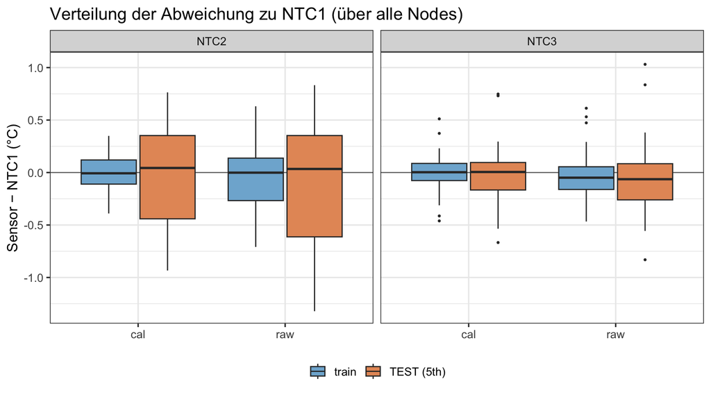

```r
res |>
  mutate(set = factor(ifelse(set == "test", "TEST (5th)", "train"),
                      levels = c("train", "TEST (5th)")),
         grp = paste(type)) |>
  ggplot(aes(x = type, y = resid, fill = set)) +
  geom_hline(yintercept = 0, linewidth = 0.4, colour = "grey40") +
  geom_boxplot(outlier.size = 0.6, position = position_dodge(0.8)) +
  facet_wrap(~ sensor) +
  scale_fill_manual(values = c(train = "#7fb3d5", `TEST (5th)` = "#e59866")) +
  labs(title = "Verteilung der Abweichung zu NTC1 (über alle Nodes)",
       x = NULL, y = "Sensor − NTC1 (°C)", fill = NULL) +
  theme_bw(base_size = 13) + theme(legend.position = "bottom")
```

### Profile of the 5th message — NTC1 truth vs. raw / calibrated

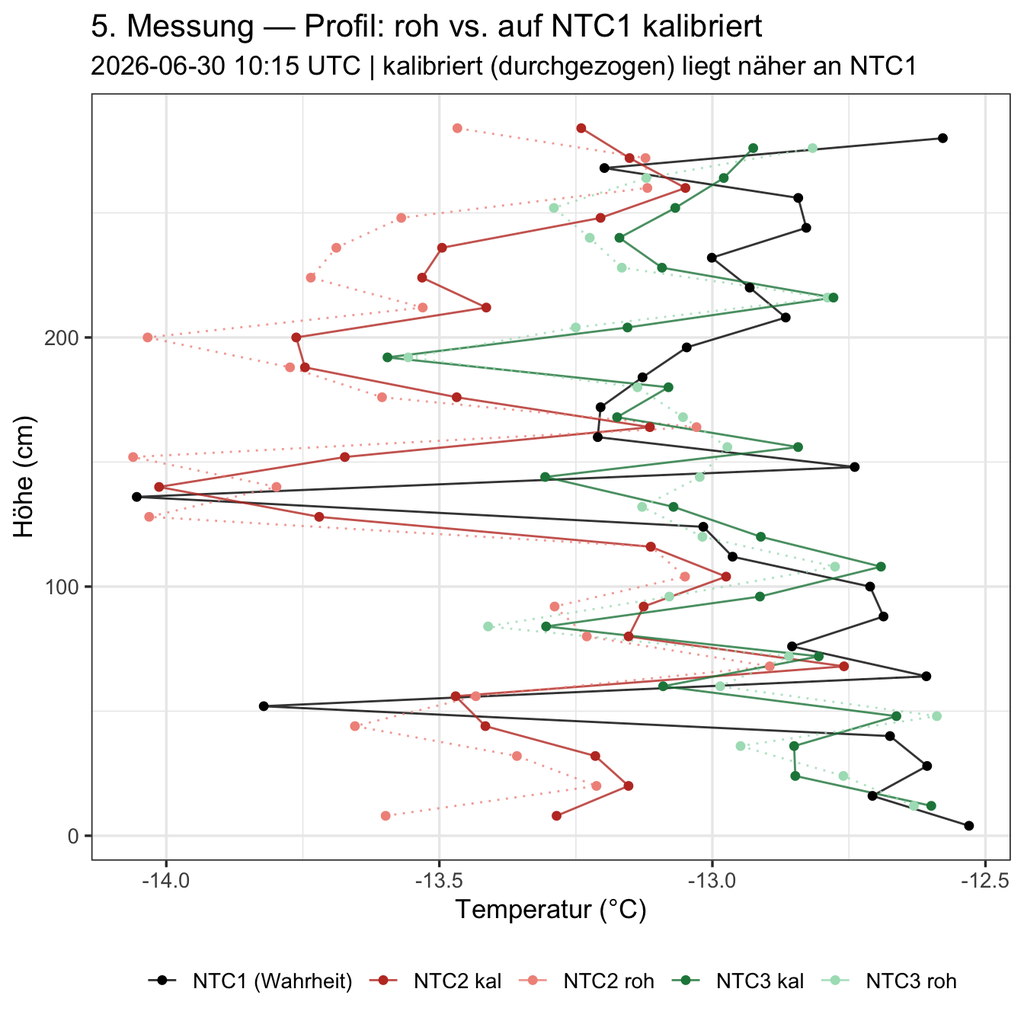

```r
# Height of each NTC as in the field-decoder profile plot.
prof <- df |> filter(msg == test[1]) |>
  transmute(node,
            `NTC1 (Wahrheit)` = NTC1,
            `NTC2 roh` = NTC2, `NTC2 kal` = NTC2_cal,
            `NTC3 roh` = NTC3, `NTC3 kal` = NTC3_cal) |>
  pivot_longer(-node, names_to = "trace", values_to = "temp_C") |>
  filter(is.finite(temp_C)) |>
  mutate(ntc      = substr(trace, 1, 4),
         ntc_rank = match(ntc, c("NTC1", "NTC2", "NTC3")),
         hoehe_cm = (node - 1L) * 3L * spacing + ntc_rank * spacing,
         kind     = case_when(grepl("Wahrheit", trace) ~ "truth",
                              grepl("roh", trace) ~ "raw", TRUE ~ "cal"))

ggplot(prof, aes(x = temp_C, y = hoehe_cm, colour = trace)) +
  geom_path(aes(group = trace, linetype = kind), alpha = 0.8) +
  geom_point(size = 1.6) +
  scale_colour_manual(values = c(
    "NTC1 (Wahrheit)" = "black",
    "NTC2 roh" = "#f1948a", "NTC2 kal" = "#c0392b",
    "NTC3 roh" = "#a9dfbf", "NTC3 kal" = "#1e8449")) +
  scale_linetype_manual(values = c(truth = "solid", raw = "dotted", cal = "solid"),
                        guide = "none") +
  labs(title = "5. Messung — Profil: roh vs. auf NTC1 kalibriert",
       subtitle = sprintf("%s UTC | kalibriert (durchgezogen) liegt näher an NTC1",
                          format(times[test[1]], "%Y-%m-%d %H:%M")),
       x = "Temperatur (°C)", y = "Höhe (cm)", colour = NULL) +
  theme_bw(base_size = 13) + theme(legend.position = "bottom")
```

### Example node fits (NTC1 vs. NTC2 / NTC3)

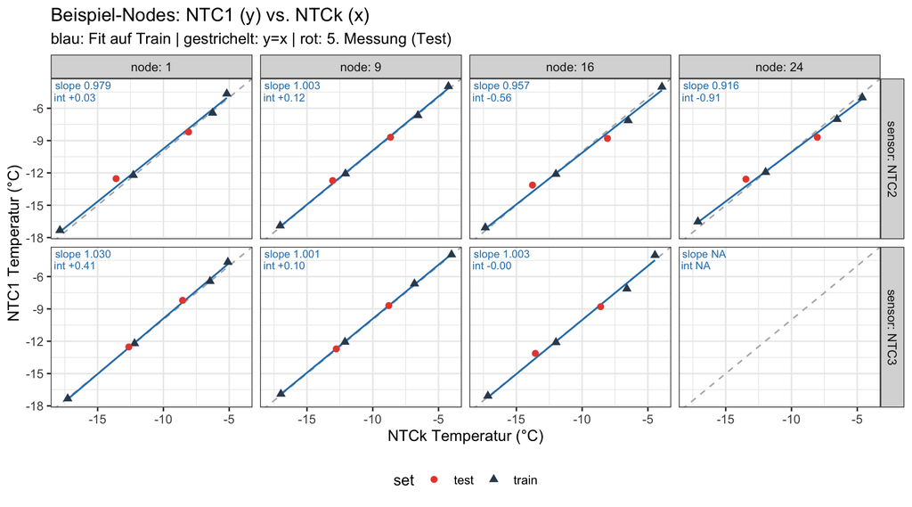

```r
# A few nodes spread across the column: training points + fitted line, with the
# held-out 5th point marked.
ex_nodes <- round(seq(1, n_nodes, length.out = 4))
fit_df <- df |> filter(node %in% ex_nodes) |>
  select(node, set, NTC1, NTC2, NTC3) |>
  pivot_longer(c(NTC2, NTC3), names_to = "sensor", values_to = "sensor_T") |>
  filter(is.finite(sensor_T), is.finite(NTC1))

# Per-panel slope/intercept from the per-node fits (NTC1 ~ NTCk on train).
ann <- do.call(rbind, lapply(ex_nodes, function(nd) rbind(
  data.frame(node = nd, sensor = "NTC2", slope = cal2$b[nd], intercept = cal2$a[nd]),
  data.frame(node = nd, sensor = "NTC3", slope = cal3$b[nd], intercept = cal3$a[nd])))) |>
  mutate(label = sprintf("slope %.3f\nint %+.2f", slope, intercept))

ggplot(fit_df, aes(x = sensor_T, y = NTC1)) +
  geom_abline(slope = 1, intercept = 0, colour = "grey70", linetype = "dashed") +
  geom_smooth(data = ~ filter(.x, set == "train"),
              method = "lm", se = FALSE, colour = "#2980b9", linewidth = 0.6) +
  geom_point(aes(shape = set, colour = set), size = 2) +
  geom_text(data = ann, aes(x = -Inf, y = Inf, label = label), inherit.aes = FALSE,
            hjust = -0.08, vjust = 1.15, size = 2.7, colour = "#2980b9", lineheight = 0.9) +
  facet_grid(sensor ~ node, labeller = label_both) +
  scale_colour_manual(values = c(train = "#34495e", test = "#e74c3c")) +
  labs(title = "Beispiel-Nodes: NTC1 (y) vs. NTCk (x)",
       subtitle = "blau: Fit auf Train | gestrichelt: y=x | rot: 5. Messung (Test)",
       x = "NTCk Temperatur (°C)", y = "NTC1 Temperatur (°C)") +
  theme_bw(base_size = 11) + theme(legend.position = "bottom")
```

## Ergebnis-Plots (kalibriert)

The same time-series figures as in `decode_field.qmd` (Hovmöller heatmap + line plot), but with the **calibrated** values: NTC1 unchanged, NTC2 and NTC3 mapped onto NTC1 with their per-node fit. The per-node NTC triplets should now collapse, so the heatmap looks vertically smoother and the lines bundle tighter.

```r
s <- spacing
cal_long <- df |>
  transmute(node, time, NTC1 = NTC1, NTC2 = NTC2_cal, NTC3 = NTC3_cal) |>
  pivot_longer(c(NTC1, NTC2, NTC3), names_to = "sensor", values_to = "temp_C") |>
  filter(is.finite(temp_C)) |>
  mutate(ntc_rank = match(sensor, c("NTC1", "NTC2", "NTC3")),
         hoehe_cm = (node - 1L) * 3L * s + ntc_rank * s)
tlevels  <- format(sort(unique(cal_long$time)), "%m-%d %H:%M")
cal_long <- cal_long |> mutate(tlab = factor(format(time, "%m-%d %H:%M"), levels = tlevels))
max_h <- n_nodes * 3L * s
```

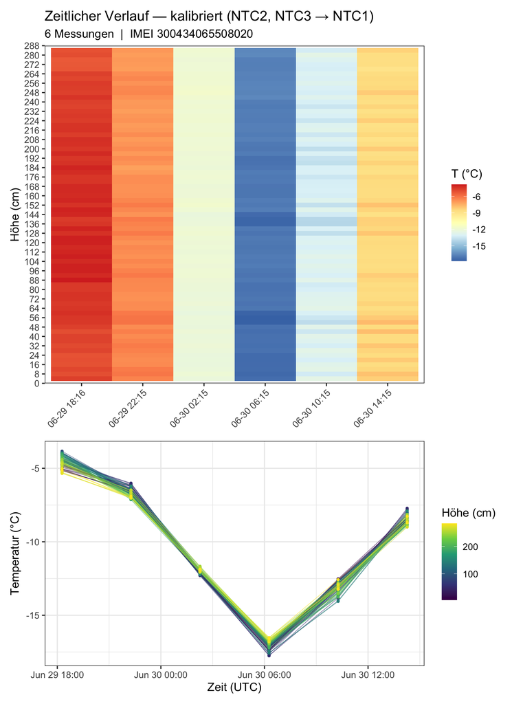

```r
p_heat <- ggplot(cal_long, aes(x = tlab, y = hoehe_cm, fill = temp_C)) +
  geom_tile() +
  scale_fill_distiller(palette = "RdYlBu", direction = -1, name = "T (°C)") +
  scale_y_continuous(name = "Höhe (cm)", limits = c(0, max_h),
                     breaks = seq(0, max_h, by = max(s, 8L)), expand = c(0, 0)) +
  labs(title    = "Zeitlicher Verlauf — kalibriert (NTC2, NTC3 → NTC1)",
       subtitle = sprintf("%d Messungen  |  IMEI %s", n_msg, IMEI),
       x = NULL) +
  theme_bw(base_size = 13) +
  theme(axis.text.x = element_text(angle = 45, hjust = 1),
        panel.grid  = element_blank())

p_line <- ggplot(cal_long, aes(x = time, y = temp_C,
                               group = interaction(node, sensor), colour = hoehe_cm)) +
  geom_line(alpha = 0.5, linewidth = 0.4) +
  geom_point(size = 1) +
  scale_colour_viridis_c(name = "Höhe (cm)") +
  labs(x = "Zeit (UTC)", y = "Temperatur (°C)") +
  theme_bw(base_size = 13)

p_heat / p_line + plot_layout(heights = c(3, 2))
```

### Anomaly — per-timepoint height-mean removed

At each measurement time we subtract the mean temperature over **all heights**, so the common diurnal signal is gone and only the **vertical structure** (how the profile deviates from its own column mean) remains. Calibrated values.

```r
anom_long <- cal_long |>
  group_by(time) |>
  mutate(temp_anom = temp_C - mean(temp_C, na.rm = TRUE)) |>
  ungroup()
alim <- max(abs(anom_long$temp_anom), na.rm = TRUE)
```

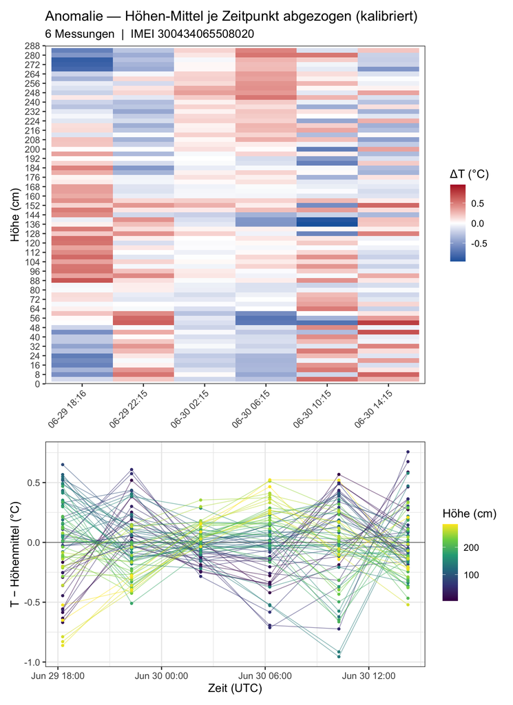

```r
a_heat <- ggplot(anom_long, aes(x = tlab, y = hoehe_cm, fill = temp_anom)) +
  geom_tile() +
  scale_fill_gradient2(low = "#2166ac", mid = "white", high = "#b2182b",
                       midpoint = 0, limits = c(-alim, alim), name = "ΔT (°C)") +
  scale_y_continuous(name = "Höhe (cm)", limits = c(0, max_h),
                     breaks = seq(0, max_h, by = max(s, 8L)), expand = c(0, 0)) +
  labs(title    = "Anomalie — Höhen-Mittel je Zeitpunkt abgezogen (kalibriert)",
       subtitle = sprintf("%d Messungen  |  IMEI %s", n_msg, IMEI),
       x = NULL) +
  theme_bw(base_size = 13) +
  theme(axis.text.x = element_text(angle = 45, hjust = 1),
        panel.grid  = element_blank())

a_line <- ggplot(anom_long, aes(x = time, y = temp_anom,
                                group = interaction(node, sensor), colour = hoehe_cm)) +
  geom_hline(yintercept = 0, linewidth = 0.4, colour = "grey50") +
  geom_line(alpha = 0.5, linewidth = 0.4) +
  geom_point(size = 1) +
  scale_colour_viridis_c(name = "Höhe (cm)") +
  labs(x = "Zeit (UTC)", y = "T − Höhenmittel (°C)") +
  theme_bw(base_size = 13)

a_heat / a_line + plot_layout(heights = c(3, 2))
```

## Save calibrated 5th message

```r
out <- df |> filter(msg == test[1]) |>
  transmute(node, time,
            NTC1, NTC2, NTC2_cal, NTC3, NTC3_cal,
            NTC2_resid_raw = NTC2 - NTC1, NTC2_resid_cal = NTC2_cal - NTC1,
            NTC3_resid_raw = NTC3 - NTC1, NTC3_resid_cal = NTC3_cal - NTC1)
outfile <- sprintf("data/calib_test_imei%s_%s.csv", IMEI,
                   format(times[test[1]], "%Y%m%d_%H%M%S"))
write.csv(out, outfile, row.names = FALSE)
cat("Saved:", outfile, "\n")
```

```
Saved: data/calib_test_imei300434065508020_20260630_101557.csv
```